# Project 2: Data Mining, Classification, Prediction

### Dimensionality Reduction with PCA

```r
prof_numeric <- profileclean %>% select(is.numeric) %>% na.omit
pca1 <- princomp(prof_numeric, cor = T)
summary(pca1, loadings = T)
```

```
## Importance of components:
##                           Comp.1    Comp.2    Comp.3     Comp.4     Comp.5
## Standard deviation     1.9730039 1.5197784 1.0984278 0.91228938 0.75588100
## Proportion of Variance 0.3892745 0.2309726 0.1206544 0.08322719 0.05713561
## Cumulative Proportion  0.3892745 0.6202471 0.7409015 0.82412865 0.88126426
##                           Comp.6     Comp.7     Comp.8     Comp.9    Comp.10
## Standard deviation     0.7077775 0.61053489 0.40378443 0.34614325 0.17549501
## Proportion of Variance 0.0500949 0.03727529 0.01630419 0.01198152 0.00307985
## Cumulative Proportion  0.9313592 0.96863445 0.98493864 0.99692015 1.00000000
##
## Loadings:
##                       Comp.1 Comp.2 Comp.3 Comp.4 Comp.5 Comp.6 Comp.7 Comp.8
## sa                            0.556  0.144         0.574  0.188  0.175  0.448
## pop                           0.530         0.138 -0.695 -0.109 -0.237  0.212
## pop_dens               0.102        -0.667  0.668  0.150  0.248 -0.110
## GDP                    0.387        -0.183 -0.135  0.321 -0.662 -0.445
## percent_unemployement        -0.129  0.627  0.701        -0.271 -0.106
## lifeex.f               0.488                      -0.125         0.269  0.195
## lifeex.m               0.472                      -0.167 -0.234  0.276  0.357
## infmort               -0.464        -0.133               -0.169 -0.327  0.514
## physicians             0.386         0.278                0.541 -0.660
## co2                           0.623                                    -0.562
##                       Comp.9 Comp.10
## sa                     0.253
## pop                    0.310
## pop_dens
## GDP                    0.226
## percent_unemployement
## lifeex.f                     -0.790
## lifeex.m              -0.468  0.516
## infmort               -0.526 -0.281
## physicians            -0.149
## co2                   -0.518 -0.106
```

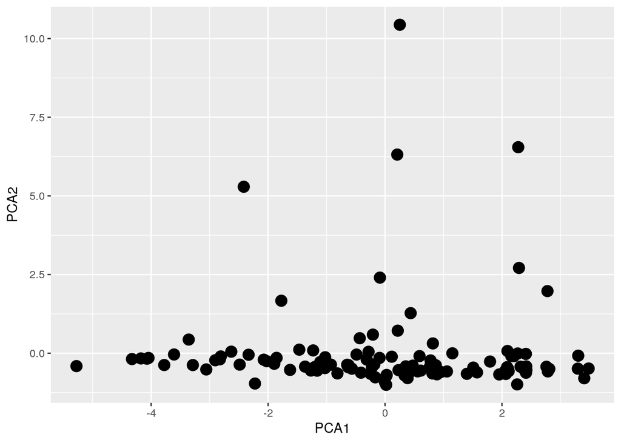

```r
pca_data <- pca1$scores %>% as.data.frame() %>% bind_cols(prof_numeric) %>%
    select(PCA1 = 1, PCA2 = 2)
pca_data %>% ggplot(aes(PCA1, PCA2)) + geom_point(size = 4)
```

After running the principal component analysis, it can be seen above that the first principal component accounts for only about 40% of the variance. The first 2 principal components account for 62% of the variability, and the first 5 principal components account for 88% of variability. A high PCA1 means that a country has a low infant mortality rate and a high population density, GDP, life expectancy for women and men, and number of physicians per 1000 people. A high PCA2 means that a country has a high surface area, population and CO2 emissions, and a low percent of unemployment.

From the scatterplot generated with PCA1 and PCA2, it can be observed that most countries have a low PCA2, although there are a few outliers. The countries are spread out across PCA1 scores however.